# Homework #6

## But what about when we DO know the data?

### Exercise 6.2

```r
# Per the homework, copy-and-paste this data chunk to access the relevant GSS data:

gss18 <- gss_get_yr(2018)
```

```
Fetching: https://gss.norc.org/documents/stata/2018_stata.zip
```

```r
d <- gss18 |>
  select(sex, attend, polviews) |>
  haven::zap_missing() |>
  mutate(sex = as_factor(sex)) |>
  haven::zap_labels() |>
  drop_na()

glimpse(d)
```

```
Rows: 2,235
Columns: 3
$ sex      <fct> male, male, female, male, female, female, male, female, male,…
$ attend   <dbl> 5, 2, 6, 8, 4, 7, 7, 0, 4, 5, 0, 3, 0, 7, 1, 0, 4, 5, 2, 7, 1…
$ polviews <dbl> 6, 5, 4, 7, 3, 4, 5, 4, 6, 4, 4, 3, 2, 5, 2, 6, 2, 4, 6, 6, 4…
```

### Exercise 6.2.2

```r
d <- d |>
  mutate(conservative = if_else(polviews >= 5, 1L, 0L),
         weekly = if_else(attend >= 7, 1L, 0L)) |>
  select(conservative, weekly) |>
  drop_na() |>
  mutate(polviews = if_else(conservative == 1, "Conservative", "Not_Conservative"))

# Now, create a cross-tabulation:
d |>
  tabyl(conservative, weekly) |>
  adorn_percentages("row") |>
  adorn_pct_formatting(digits = 2) |>
  adorn_ns()
```

```
 conservative              0            1
            0 82.87% (1,243) 17.13% (257)
            1 67.35%   (495) 32.65% (240)
```

### Exercise 6.2.3

```r
# Let's figure out if the difference in proportions between "conservative" and "weekly" is statistically significant:

# Create a "bootstrap" distribution:
boot_dist <-
  d |>
  specify(weekly ~ polviews) |>
  generate(reps = 1000,
           type = "bootstrap") |>
  calculate(stat = "diff in means",
            order = c("Conservative", "Not_Conservative"))

# Create a confidence interval to test the distribution:
conf_int <- boot_dist |>
  get_confidence_interval(level = .95)

# Then, run the confidence interval test:
conf_int
```

```
# A tibble: 1 × 2
  lower_ci upper_ci
     <dbl>    <dbl>
1    0.116    0.193
```

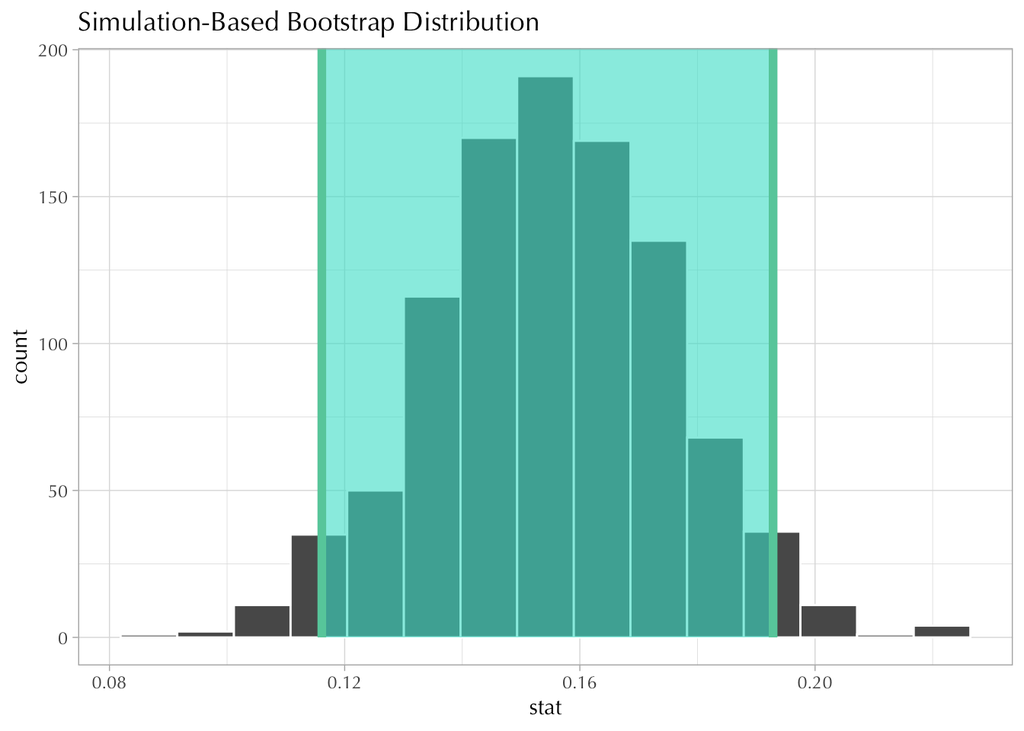

```r
# Visualizing the distribution with confidence intervals:
boot_dist |> visualize() + shade_ci(conf_int)
```

```r
# Now, test the hypotheses:
observed_difference <- mean(d$weekly[d$polviews=="Conservative"]) -
  mean(d$weekly[d$polviews=="Not_Conservative"])

# Build the null hypothesis distribution:
null_dist <- d |>
  specify(weekly ~ polviews) |>
  hypothesize(null = "independence") |>
  generate(reps = 1000,
           type = "permute") |>
  calculate(stat = "diff in means",
            order = c("Conservative", "Not_Conservative"))

# Find the p value:
null_dist |>
  get_p_value(observed_difference,
              direction = "both")
```

```
# A tibble: 1 × 1
  p_value
    <dbl>
1       0
```

### Exercise 6.2.3

Interpreting through geom_tile:

The first graphic, “Counts,” appears to indicate that most respondents identified their political views with a 4, making the self-report of politically “moderate” the most common.

Lastly, the third graphic, “Column Percentages,” shows the breakdown of each column on the basis of political views and attendance—namely, demonstrating that respondents who identified as “moderate” appear to attend religious services between the range of 0-8 (“never” to “several times a week”).

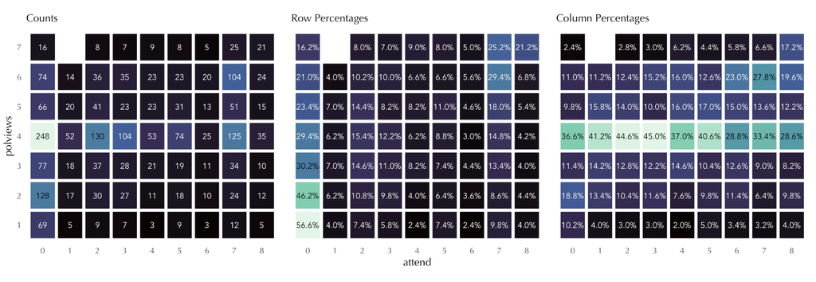